## Car Evaluation Sample Project - Part 3

### Car Evaluation Dataset: https://archive.ics.uci.edu/ml/datasets/Car+Evaluation

# Third Step: Exploratory Analysis

### Analyzing Individual Feature Patterns Using Visualization

```python
import matplotlib.pyplot as plt
import seaborn as sns
%matplotlib inline
```

```python
# list the data types for each column
print(df.dtypes)
```

```
symboling               int64
normalized-losses       int32
make                   object
num-of-doors           object
body-style             object
drive-wheels           object
engine-location        object
wheel-base            float64
length                float64
width                 float64
height                float64
curb-weight             int64
engine-type            object
num-of-cylinders       object
engine-size             int64
fuel-system            object
bore                  float64
stroke                float64
compression-ratio     float64
horsepower              int32
peak-rpm              float64
city-mpg                int64
highway-mpg             int64
price                 float64
city-L/100km          float64
horsepower-binned    category
fuel-type-diesel        uint8
fuel-type-gas           uint8
aspiration-std          uint8
aspiration-turbo        uint8
dtype: object
```

#### calculate the correlation between variables of type "int64" or "float64"

```python
df.corr()
```

|  | symboling | normalized-losses | wheel-base | length | width | height | curb-weight | engine-size | bore | stroke | ... | horsepower | peak-rpm | city-mpg | highway-mpg | price | city-L/100km | fuel-type-diesel | fuel-type-gas | aspiration-std | aspiration-turbo |
| --- | --- | --- | --- | --- | --- | --- | --- | --- | --- | --- | --- | --- | --- | --- | --- | --- | --- | --- | --- | --- | --- |
| symboling | 1.000000 | 0.469772 | -0.529145 | -0.364511 | -0.237262 | -0.542261 | -0.234743 | -0.112069 | -0.145790 | 0.008072 | ... | 0.074617 | 0.284033 | -0.030158 | 0.041248 | -0.083327 | 0.062423 | -0.195381 | 0.195381 | 0.050995 | -0.050995 |
| normalized-losses | 0.469772 | 1.000000 | -0.057068 | 0.019433 | 0.086961 | -0.377664 | 0.099404 | 0.112362 | -0.029929 | 0.055673 | ... | 0.217322 | 0.239580 | -0.225255 | -0.182011 | 0.133999 | 0.238712 | -0.101574 | 0.101574 | 0.006915 | -0.006915 |
| wheel-base | -0.529145 | -0.057068 | 1.000000 | 0.879005 | 0.814593 | 0.583789 | 0.787584 | 0.576779 | 0.501576 | 0.144733 | ... | 0.375610 | -0.365045 | -0.480029 | -0.552211 | 0.589147 | 0.484047 | 0.306706 | -0.306706 | -0.254907 | 0.254907 |
| length | -0.364511 | 0.019433 | 0.879005 | 1.000000 | 0.857271 | 0.492955 | 0.881058 | 0.685531 | 0.610847 | 0.120929 | ... | 0.580583 | -0.286688 | -0.667658 | -0.700186 | 0.691044 | 0.659174 | 0.210616 | -0.210616 | -0.229294 | 0.229294 |
| width | -0.237262 | 0.086961 | 0.814593 | 0.857271 | 1.000000 | 0.300995 | 0.867720 | 0.731100 | 0.548485 | 0.182864 | ... | 0.617115 | -0.247337 | -0.638155 | -0.684700 | 0.752795 | 0.677111 | 0.243448 | -0.243448 | -0.304459 | 0.304459 |
| height | -0.542261 | -0.377664 | 0.583789 | 0.492955 | 0.300995 | 1.000000 | 0.310660 | 0.076255 | 0.187917 | -0.081103 | ... | -0.085829 | -0.315820 | -0.057087 | -0.111568 | 0.137284 | 0.008923 | 0.281198 | -0.281198 | -0.086531 | 0.086531 |
| curb-weight | -0.234743 | 0.099404 | 0.787584 | 0.881058 | 0.867720 | 0.310660 | 1.000000 | 0.849090 | 0.644552 | 0.168669 | ... | 0.758076 | -0.279422 | -0.750390 | -0.795515 | 0.834420 | 0.785868 | 0.221082 | -0.221082 | -0.322097 | 0.322097 |
| engine-size | -0.112069 | 0.112362 | 0.576779 | 0.685531 | 0.731100 | 0.076255 | 0.849090 | 1.000000 | 0.572878 | 0.208133 | ... | 0.822689 | -0.256681 | -0.651002 | -0.679877 | 0.872337 | 0.745337 | 0.070925 | -0.070925 | -0.110278 | 0.110278 |
| bore | -0.145790 | -0.029929 | 0.501576 | 0.610847 | 0.548485 | 0.187917 | 0.644552 | 0.572878 | 1.000000 | -0.051087 | ... | 0.566807 | -0.267061 | -0.581272 | -0.590672 | 0.543433 | 0.553954 | 0.055395 | -0.055395 | -0.229338 | 0.229338 |
| stroke | 0.008072 | 0.055673 | 0.144733 | 0.120929 | 0.182864 | -0.081103 | 0.168669 | 0.208133 | -0.051087 | 1.000000 | ... | 0.100881 | -0.066021 | -0.040547 | -0.040170 | 0.083298 | 0.041310 | 0.240046 | -0.240046 | -0.215805 | 0.215805 |
| compression-ratio | -0.181073 | -0.114738 | 0.249689 | 0.159203 | 0.189008 | 0.259526 | 0.156444 | 0.029005 | 0.002034 | 0.186780 | ... | -0.214260 | -0.436303 | 0.330897 | 0.267929 | 0.071176 | -0.298898 | 0.985228 | -0.985228 | -0.307074 | 0.307074 |
| horsepower | 0.074617 | 0.217322 | 0.375610 | 0.580583 | 0.617115 | -0.085829 | 0.758076 | 0.822689 | 0.566807 | 0.100881 | ... | 1.000000 | 0.108163 | -0.822488 | -0.804702 | 0.809657 | 0.889613 | -0.168755 | 0.168755 | -0.251799 | 0.251799 |
| peak-rpm | 0.284033 | 0.239580 | -0.365045 | -0.286688 | -0.247337 | -0.315820 | -0.279422 | -0.256681 | -0.267061 | -0.066021 | ... | 0.108163 | 1.000000 | -0.116364 | -0.059319 | -0.101593 | 0.116528 | -0.476430 | 0.476430 | 0.190772 | -0.190772 |
| city-mpg | -0.030158 | -0.225255 | -0.480029 | -0.667658 | -0.638155 | -0.057087 | -0.750390 | -0.651002 | -0.581272 | -0.040547 | ... | -0.822488 | -0.116364 | 1.000000 | 0.972024 | -0.687186 | -0.949692 | 0.264947 | -0.264947 | 0.191068 | -0.191068 |
| highway-mpg | 0.041248 | -0.182011 | -0.552211 | -0.700186 | -0.684700 | -0.111568 | -0.795515 | -0.679877 | -0.590672 | -0.040170 | ... | -0.804702 | -0.059319 | 0.972024 | 1.000000 | -0.705115 | -0.929940 | 0.197989 | -0.197989 | 0.243429 | -0.243429 |
| price | -0.083327 | 0.133999 | 0.589147 | 0.691044 | 0.752795 | 0.137284 | 0.834420 | 0.872337 | 0.543433 | 0.083298 | ... | 0.809657 | -0.101593 | -0.687186 | -0.705115 | 1.000000 | 0.790291 | 0.110417 | -0.110417 | -0.179762 | 0.179762 |
| city-L/100km | 0.062423 | 0.238712 | 0.484047 | 0.659174 | 0.677111 | 0.008923 | 0.785868 | 0.745337 | 0.553954 | 0.041310 | ... | 0.889613 | 0.116528 | -0.949692 | -0.929940 | 0.790291 | 1.000000 | -0.240676 | 0.240676 | -0.158912 | 0.158912 |
| fuel-type-diesel | -0.195381 | -0.101574 | 0.306706 | 0.210616 | 0.243448 | 0.281198 | 0.221082 | 0.070925 | 0.055395 | 0.240046 | ... | -0.168755 | -0.476430 | 0.264947 | 0.197989 | 0.110417 | -0.240676 | 1.000000 | -1.000000 | -0.407787 | 0.407787 |
| fuel-type-gas | 0.195381 | 0.101574 | -0.306706 | -0.210616 | -0.243448 | -0.281198 | -0.221082 | -0.070925 | -0.055395 | -0.240046 | ... | 0.168755 | 0.476430 | -0.264947 | -0.197989 | -0.110417 | 0.240676 | -1.000000 | 1.000000 | 0.407787 | -0.407787 |
| aspiration-std | 0.050995 | 0.006915 | -0.254907 | -0.229294 | -0.304459 | -0.086531 | -0.322097 | -0.110278 | -0.229338 | -0.215805 | ... | -0.251799 | 0.190772 | 0.191068 | 0.243429 | -0.179762 | -0.158912 | -0.407787 | 0.407787 | 1.000000 | -1.000000 |
| aspiration-turbo | -0.050995 | -0.006915 | 0.254907 | 0.229294 | 0.304459 | 0.086531 | 0.322097 | 0.110278 | 0.229338 | 0.215805 | ... | 0.251799 | -0.190772 | -0.191068 | -0.243429 | 0.179762 | 0.158912 | 0.407787 | -0.407787 | -1.000000 | 1.000000 |

21 rows × 21 columns

```python
df[['bore', 'stroke', 'compression-ratio', 'horsepower']].corr()
```

|  | bore | stroke | compression-ratio | horsepower |
| --- | --- | --- | --- | --- |
| bore | 1.000000 | -0.051087 | 0.002034 | 0.566807 |
| stroke | -0.051087 | 1.000000 | 0.186780 | 0.100881 |
| compression-ratio | 0.002034 | 0.186780 | 1.000000 | -0.214260 |
| horsepower | 0.566807 | 0.100881 | -0.214260 | 1.000000 |

#### Let's find the scatterplot of "engine-size" and "price".

```
(0.0, 53304.355388382566)
```

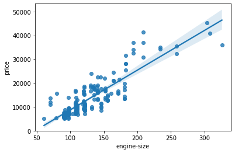

```python
# Engine size as potential predictor variable of price
sns.regplot(x="engine-size", y="price", data=df)
plt.ylim(0,)
```

#### We can examine the correlation between 'engine-size' and 'price' and see that it's approximately 0.87.

```python
df[["engine-size", "price"]].corr()
```

|  | engine-size | price |
| --- | --- | --- |
| engine-size | 1.000000 | 0.872337 |
| price | 0.872337 | 1.000000 |

#### Highway mpg is a potential predictor variable of price. Let's find the scatterplot of "highway-mpg" and "price".

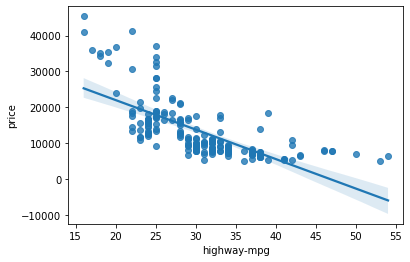

```python
sns.regplot(x="highway-mpg", y="price", data=df)
```

```python
df[['highway-mpg', 'price']].corr()
```

|  | highway-mpg | price |
| --- | --- | --- |
| highway-mpg | 1.000000 | -0.705115 |
| price | -0.705115 | 1.000000 |

#### Let's see if "peak-rpm" is a predictor variable of "price".

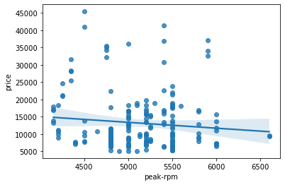

```python
sns.regplot(x="peak-rpm", y="price", data=df)
```

Peak rpm does not seem like a good predictor of the price at all since the regression line is close to horizontal

```python
df[['peak-rpm','price']].corr()
```

|  | peak-rpm | price |
| --- | --- | --- |
| peak-rpm | 1.000000 | -0.101593 |
| price | -0.101593 | 1.000000 |

```python
df[["stroke","price"]].corr()
```

|  | stroke | price |
| --- | --- | --- |
| stroke | 1.000000 | 0.083298 |
| price | 0.083298 | 1.000000 |

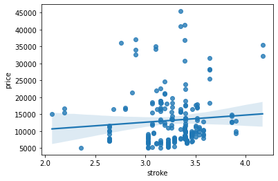

```python
sns.regplot(x="stroke", y="price", data=df)
```

There is a weak correlation between the variable 'stroke' and 'price'

### Categorical Variables

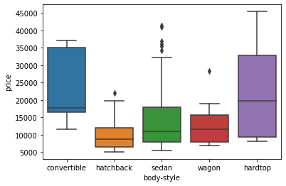

```python
#check body-style
sns.boxplot(x="body-style", y="price", data=df)
```

We see that the distributions of price between the different body-style categories have a significant overlap, so body-style would not be a good predictor of price

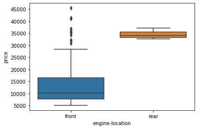

```python
sns.boxplot(x="engine-location", y="price", data=df)
```

Here we see that the distribution of price between these two engine-location categories, front and rear, are distinct enough to take engine-location as a potential good predictor of price.

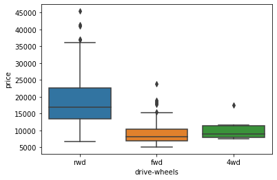

```python
# check drive-wheels
sns.boxplot(x="drive-wheels", y="price", data=df)
```

Here we see that the distribution of price between the different drive-wheels categories differs. As such, drive-wheels could potentially be a predictor of price.

### Descriptive Statistical Analysis

```python
df.describe()
```

|  | symboling | normalized-losses | wheel-base | length | width | height | curb-weight | engine-size | bore | stroke | ... | horsepower | peak-rpm | city-mpg | highway-mpg | price | city-L/100km | fuel-type-diesel | fuel-type-gas | aspiration-std | aspiration-turbo |
| --- | --- | --- | --- | --- | --- | --- | --- | --- | --- | --- | --- | --- | --- | --- | --- | --- | --- | --- | --- | --- | --- |
| count | 200.000000 | 200.000000 | 200.000000 | 200.000000 | 200.000000 | 200.000000 | 200.000000 | 200.000000 | 200.000000 | 200.000000 | ... | 200.000000 | 200.000000 | 200.000000 | 200.000000 | 200.000000 | 200.000000 | 200.000000 | 200.000000 | 200.000000 | 200.000000 |
| mean | 0.830000 | 122.000000 | 98.848000 | 0.837232 | 0.915250 | 0.899523 | 2555.705000 | 126.860000 | 3.329981 | 3.259816 | ... | 103.365000 | 5118.259901 | 25.200000 | 30.705000 | 13205.690000 | 9.937914 | 0.100000 | 0.900000 | 0.820000 | 0.180000 |
| std | 1.248557 | 32.076542 | 6.038261 | 0.059333 | 0.029207 | 0.040610 | 518.594552 | 41.650501 | 0.268562 | 0.314177 | ... | 37.455525 | 479.240743 | 6.432487 | 6.827227 | 7966.982558 | 2.539415 | 0.300753 | 0.300753 | 0.385152 | 0.385152 |
| min | -2.000000 | 65.000000 | 86.600000 | 0.678039 | 0.837500 | 0.799331 | 1488.000000 | 61.000000 | 2.540000 | 2.070000 | ... | 48.000000 | 4150.000000 | 13.000000 | 16.000000 | 5118.000000 | 4.795918 | 0.000000 | 0.000000 | 0.000000 | 0.000000 |
| 25% | 0.000000 | 100.250000 | 94.500000 | 0.800937 | 0.891319 | 0.869565 | 2163.000000 | 97.750000 | 3.150000 | 3.117500 | ... | 70.000000 | 4800.000000 | 19.000000 | 25.000000 | 7775.000000 | 7.833333 | 0.000000 | 1.000000 | 1.000000 | 0.000000 |
| 50% | 1.000000 | 122.000000 | 97.000000 | 0.832292 | 0.909722 | 0.904682 | 2414.000000 | 119.500000 | 3.310000 | 3.290000 | ... | 95.000000 | 5162.995050 | 24.000000 | 30.000000 | 10270.000000 | 9.791667 | 0.000000 | 1.000000 | 1.000000 | 0.000000 |
| 75% | 2.000000 | 138.250000 | 102.400000 | 0.881788 | 0.926042 | 0.928512 | 2928.250000 | 142.000000 | 3.582500 | 3.410000 | ... | 116.000000 | 5500.000000 | 30.000000 | 34.000000 | 16500.750000 | 12.368421 | 0.000000 | 1.000000 | 1.000000 | 0.000000 |
| max | 3.000000 | 256.000000 | 120.900000 | 1.000000 | 1.000000 | 1.000000 | 4066.000000 | 326.000000 | 3.940000 | 4.170000 | ... | 262.000000 | 6600.000000 | 49.000000 | 54.000000 | 45400.000000 | 18.076923 | 1.000000 | 1.000000 | 1.000000 | 1.000000 |

8 rows × 21 columns

### The default setting of "describe" skips variables of type object. We can apply the method "describe" on the variables of type 'object' as follows:

```python
df.describe(include=['object'])
```

|  | make | num-of-doors | body-style | drive-wheels | engine-location | engine-type | num-of-cylinders | fuel-system |
| --- | --- | --- | --- | --- | --- | --- | --- | --- |
| count | 200 | 200 | 200 | 200 | 200 | 200 | 200 | 200 |
| unique | 22 | 2 | 5 | 3 | 2 | 6 | 7 | 8 |
| top | toyota | four | sedan | fwd | front | ohc | four | mpfi |
| freq | 32 | 115 | 94 | 118 | 197 | 145 | 156 | 91 |

#### Value Counts

```python
df['drive-wheels'].value_counts()
```

```
fwd    118
rwd     74
4wd      8
Name: drive-wheels, dtype: int64
```

#### We can convert the series to a dataframe as follows:

```python
df['drive-wheels'].value_counts().to_frame()
```

|  | drive-wheels |
| --- | --- |
| fwd | 118 |
| rwd | 74 |
| 4wd | 8 |

#### Let's repeat the above steps but save the results to the dataframe "drive_wheels_counts" and rename the column 'drive-wheels' to 'value_counts':

```python
drive_wheels_counts = df['drive-wheels'].value_counts().to_frame()
drive_wheels_counts.rename(columns={'drive-wheels': 'value_counts'}, inplace=True)
drive_wheels_counts
```

|  | value_counts |
| --- | --- |
| fwd | 118 |
| rwd | 74 |
| 4wd | 8 |

#### Now let's rename the index to 'drive-wheels':

```python
drive_wheels_counts.index.name = 'drive-wheels'
drive_wheels_counts
```

| drive-wheels | value_counts |
| --- | --- |
| fwd | 118 |
| rwd | 74 |
| 4wd | 8 |

#### We can repeat the above process for the variable 'engine-location'.

```python
# engine-location as variable
engine_loc_counts = df['engine-location'].value_counts().to_frame()
engine_loc_counts.rename(columns={'engine-location': 'value_counts'}, inplace=True)
engine_loc_counts.index.name = 'engine-location'
engine_loc_counts.head(10)
```

| engine-location | value_counts |
| --- | --- |
| front | 197 |
| rear | 3 |

### Correlation and Causation

- p-value is $<$ 0.001: we say there is strong evidence that the correlation is significant.
- the p-value is $<$ 0.05: there is moderate evidence that the correlation is significant.
- the p-value is $<$ 0.1: there is weak evidence that the correlation is significant.
- the p-value is $>$ 0.1: there is no evidence that the correlation is significant.

```python
from scipy import stats
```

#### Let's calculate the Pearson Correlation Coefficient and P-value of 'wheel-base' and 'price'.

```python
pearson_coef, p_value = stats.pearsonr(df['wheel-base'], df['price'])
print("The Pearson Correlation Coefficient is", pearson_coef, " with a P-value of P =", p_value)
```

```
The Pearson Correlation Coefficient is 0.5891470005448702  with a P-value of P = 4.4570195020504053e-20
```

Since the p-value is < 0.001, the correlation between wheel-base and price is statistically significant, although the linear relationship isn't extremely strong (~0.589).

#### Let's calculate the Pearson Correlation Coefficient and P-value of 'horsepower' and 'price'.

```python
pearson_coef, p_value = stats.pearsonr(df['horsepower'], df['price'])
print("The Pearson Correlation Coefficient is", pearson_coef, " with a P-value of P = ", p_value)
```

```
The Pearson Correlation Coefficient is 0.8096565575365611  with a P-value of P =  1.0468839625927006e-47
```

Since the p-value is < 0.001, the correlation between horsepower and price is statistically significant, and the linear relationship is quite strong (~0.809, close to 1).

#### Let's calculate the Pearson Correlation Coefficient and P-value of 'length' and 'price'.

```python
pearson_coef, p_value = stats.pearsonr(df['length'], df['price'])
print("The Pearson Correlation Coefficient is", pearson_coef, " with a P-value of P = ", p_value)
```

```
The Pearson Correlation Coefficient is 0.6910440897821903  with a P-value of P =  9.96096322234889e-30
```

Since the p-value is < 0.001, the correlation between length and price is statistically significant, and the linear relationship is moderately strong (~0.691).

#### Let's calculate the Pearson Correlation Coefficient and P-value of 'width' and 'price':

```python
pearson_coef, p_value = stats.pearsonr(df['width'], df['price'])
print("The Pearson Correlation Coefficient is", pearson_coef, " with a P-value of P =", p_value )
```

```
The Pearson Correlation Coefficient is 0.7527948631832608  with a P-value of P = 8.256714148309272e-38
```

Since the p-value is < 0.001, the correlation between width and price is statistically significant, and the linear relationship is quite strong (~0.752).

#### Let's calculate the Pearson Correlation Coefficient and P-value of 'curb-weight' and 'price':

```python
pearson_coef, p_value = stats.pearsonr(df['curb-weight'], df['price'])
print( "The Pearson Correlation Coefficient is", pearson_coef, " with a P-value of P = ", p_value)
```

```
The Pearson Correlation Coefficient is 0.8344204348498461  with a P-value of P =  3.9699775360220333e-53
```

Since the p-value is < 0.001, the correlation between curb-weight and price is statistically significant, and the linear relationship is quite strong (~0.834)

#### Let's calculate the Pearson Correlation Coefficient and P-value of 'engine-size' and 'price':

```python
pearson_coef, p_value = stats.pearsonr(df['engine-size'], df['price'])
print("The Pearson Correlation Coefficient is", pearson_coef, " with a P-value of P =", p_value)
```

```
The Pearson Correlation Coefficient is 0.8723367498521142  with a P-value of P = 1.8977171466563487e-63
```

Since the p-value is < 0.001, the correlation between engine-size and price is statistically significant, and the linear relationship is very strong (~0.872).

#### Let's calculate the Pearson Correlation Coefficient and P-value of 'bore' and 'price':

```python
pearson_coef, p_value = stats.pearsonr(df['bore'], df['price'])
print("The Pearson Correlation Coefficient is", pearson_coef, " with a P-value of P =  ", p_value )
```

```
The Pearson Correlation Coefficient is 0.5434325935555682  with a P-value of P =   9.207487524195266e-17
```

#### Let's calculate the Pearson Correlation Coefficient and P-value of 'city-mpg' and 'price':

```python
pearson_coef, p_value = stats.pearsonr(df['city-mpg'], df['price'])
print("The Pearson Correlation Coefficient is", pearson_coef, " with a P-value of P = ", p_value)
```

```
The Pearson Correlation Coefficient is -0.6871861020862686  with a P-value of P =  2.729256568479228e-29
```

Since the p-value is < 0.001, the correlation between city-mpg and price is statistically significant, and the coefficient of about -0.687 shows that the relationship is negative and moderately strong.

#### Let's calculate the Pearson Correlation Coefficient and P-value of 'highway-mpg' and 'price':

```python
pearson_coef, p_value = stats.pearsonr(df['highway-mpg'], df['price'])
print( "The Pearson Correlation Coefficient is", pearson_coef, " with a P-value of P = ", p_value )
```

```
The Pearson Correlation Coefficient is -0.7051147088046402  with a P-value of P =  2.197326053158553e-31
```

Since the p-value is < 0.001, the correlation between highway-mpg and price is statistically significant, and the coefficient of about -0.705 shows that the relationship is negative and moderately strong.

## Conclusion:

#### Important continous numerical variables:

Length  
Width  
Curb-weight  
Engine-size  
Horsepower  
City-mpg  
Highway-mpg  
Wheel-base  
Bore

#### Important categorical variables:

Drive-wheels